# Indel Signature InsDel_N_beta

# InsDel_Nβ

(corresponds to 83-type signature ID_N)

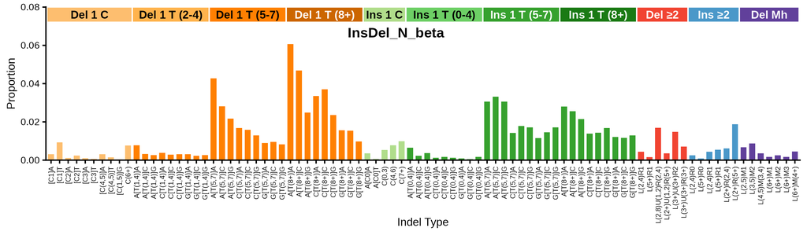

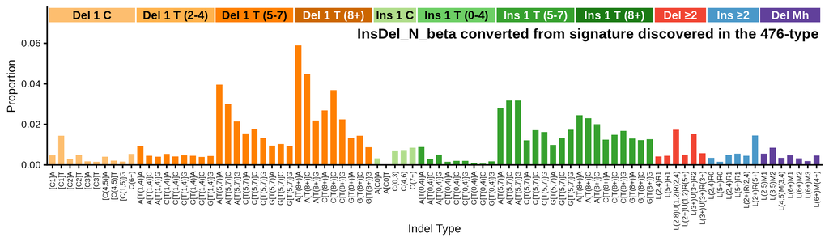

89-type spectrum of the linking tumor SP111038 | cosine similarity to InsDel_N_beta: 0.985

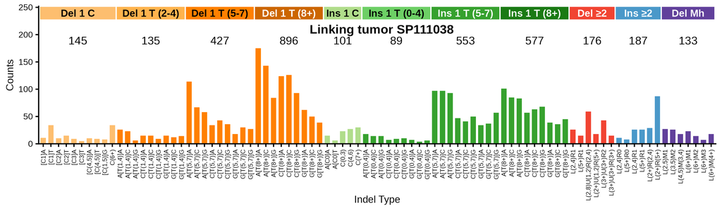

**Click to view decomposition of the linking tumor spectrum**

Partial mutation signature of SP111038 due to InsDel_N_beta

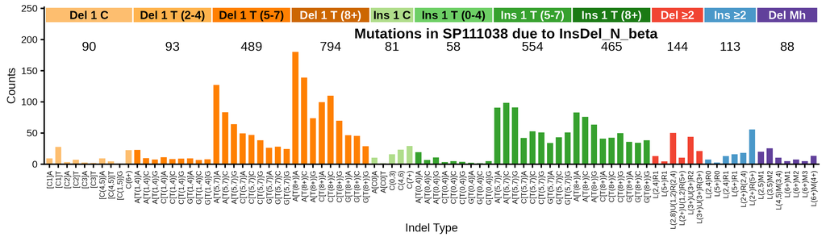

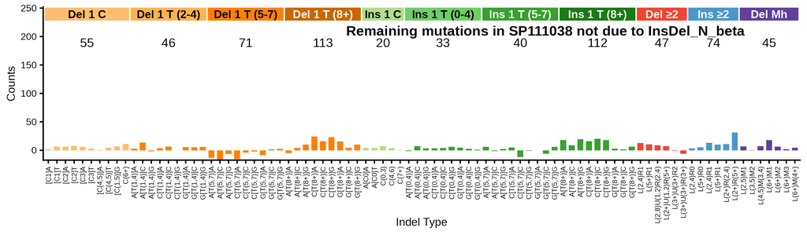

Max neg fraction (maximum allowed negative residual count as fraction of total): 0.03  
N subtract (mutation count assigned to signature): 2968.7  
N residual (mutation count in residual “partial spectrum”): 450.3  
Total negative (sum of negative residual mutation counts): 102.4  
N negative channels (number of channels with negative residual): 18  
P(≥ total negative) (Monte Carlo estimated probability that negative-binomial-sampled spectra from the signature contributing N subtract mutations would produce a total negative count >= the observed Total negative; higher number means not surprising): 0.999

**Per-channel residual breakdown**

| Channel | Spectrum | Sig_Count | Residual | Sig_Prop |
| --- | --- | --- | --- | --- |
| [Del(C):R1]A | 11 | 9.3 | 1.7 | 0.00315 |
| [Del(C):R1]T | 34 | 27.6 | 6.4 | 0.00931 |
| [Del(C):R2]A | 10 | 3.4 | 6.6 | 0.00116 |
| [Del(C):R2]T | 15 | 7.2 | 7.8 | 0.00242 |
| [Del(C):R3]A | 9 | 2.9 | 6.1 | 0.00099 |
| [Del(C):R3]T | 5 | 2.1 | 2.9 | 0.00070 |
| [Del(C):R(4,5)]A | 10 | 9.3 | 0.7 | 0.00313 |
| [Del(C):R(4,5)]T | 9 | 4.5 | 4.5 | 0.00152 |
| [Del(C):R(1,5)]G | 8 | 1.2 | 6.8 | 0.00040 |
| Del(C):R(6,9) | 34 | 22.6 | 11.4 | 0.00761 |
| A[Del(T):R(1,4)]A | 26 | 23.0 | 3 | 0.00773 |
| A[Del(T):R(1,4)]C | 23 | 9.6 | 13.4 | 0.00323 |
| A[Del(T):R(1,4)]G | 6 | 7.7 | -1.7 | 0.00260 |
| C[Del(T):R(1,4)]A | 15 | 11.1 | 3.9 | 0.00375 |
| C[Del(T):R(1,4)]C | 15 | 8.4 | 6.6 | 0.00282 |
| C[Del(T):R(1,4)]G | 9 | 9.2 | -0.2 | 0.00309 |
| G[Del(T):R(1,4)]A | 15 | 9.3 | 5.7 | 0.00313 |
| G[Del(T):R(1,4)]C | 12 | 6.8 | 5.2 | 0.00229 |
| G[Del(T):R(1,4)]G | 14 | 7.9 | 6.1 | 0.00266 |
| A[Del(T):R(5,7)]A | 114 | 127.0 | -13 | 0.04280 |
| A[Del(T):R(5,7)]C | 67 | 83.5 | -16.5 | 0.02812 |
| A[Del(T):R(5,7)]G | 58 | 64.4 | -6.4 | 0.02169 |
| C[Del(T):R(5,7)]A | 34 | 49.7 | -15.7 | 0.01674 |
| C[Del(T):R(5,7)]C | 43 | 46.9 | -3.9 | 0.01581 |
| C[Del(T):R(5,7)]G | 36 | 38.3 | -2.3 | 0.01291 |
| G[Del(T):R(5,7)]A | 18 | 26.5 | -8.5 | 0.00892 |
| G[Del(T):R(5,7)]C | 30 | 28.2 | 1.8 | 0.00948 |
| G[Del(T):R(5,7)]G | 27 | 24.4 | 2.6 | 0.00822 |
| A[Del(T):R(8,)]A | 175 | 180.1 | -5.1 | 0.06066 |
| A[Del(T):R(8,)]C | 143 | 139.0 | 4 | 0.04681 |

[output cut: 59 more lines]

**Click to view similar signatures from Koh et al.**

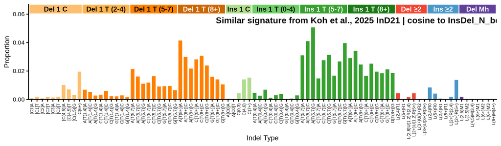

## 476-type representations corresponding to InsDel_N_beta

Extracted 476-type signature corresponding to InsDel_N_beta

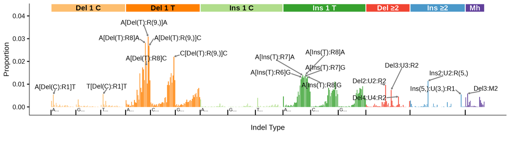

476-type spectrum of the linking tumor SP111038; cosine similarity to the extracted 476-type signature is 0.9673

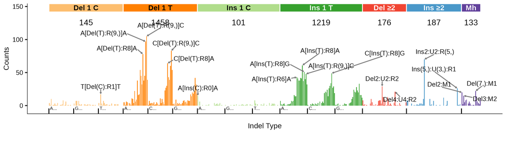

## 83-type signature corresponding to InsDel_N_beta (ID_N)

**Note**

ID_N can be decomposed into C_ID1 and C_ID2. Nevertheless, We think it is a novel signature rather than a combination of two signatures because (1) it was found in both SigProfiler and mSigHdp and (2) we found the corresponding 89-type/476-type signatures (InsDel_N_alpha and InsDel_N_beta).

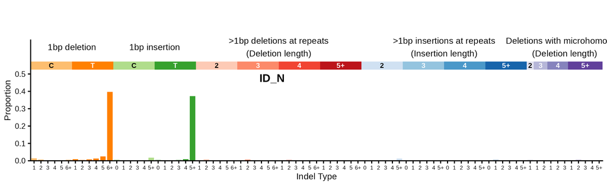

**Click here to see with insertions and deletions of T in long poly-T suppressed**

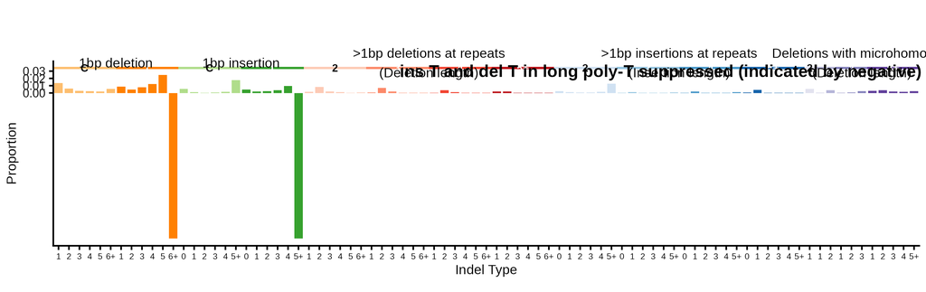

83-type signature converted from signature discovered in the 476-type spectra (using bipartite matching optimization) | cosine similarity to ID_N: 0.9982

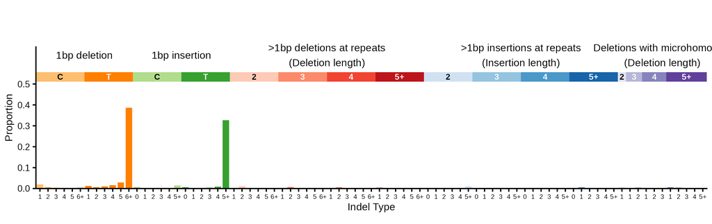

**Click here to see with insertions and deletions of T in long poly-T suppressed**

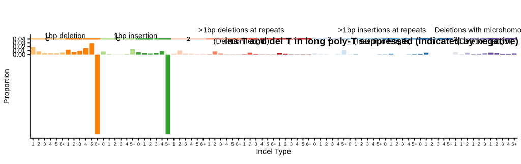

**Click to see flow diagrams: 476-type to 83-type collapse**

These Sankey diagrams show how the 476-type mutation categories are redistributed to 83-type categories using bipartite matching. We only show the diagrams for insertions or deletions of > 1 base because it is for these indels that 476-type categories map to > 1 83-type category.

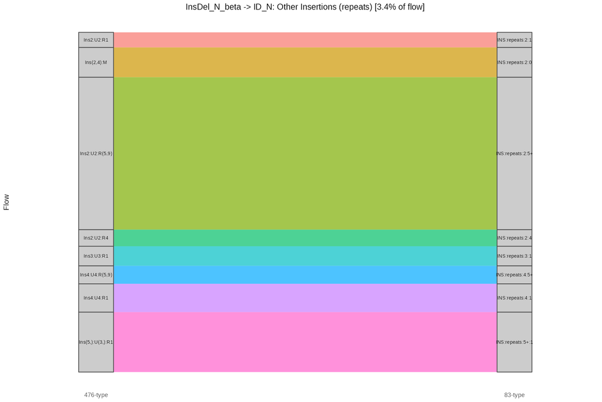

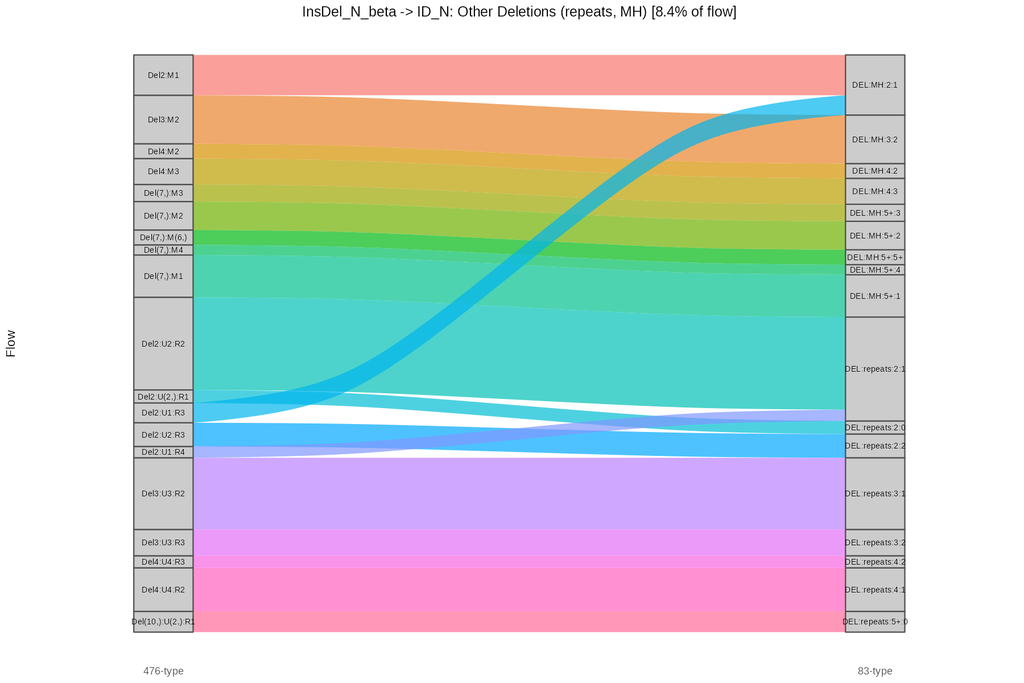

83-type spectrum of the linking tumor SP111038 | cosine similarity to ID_N: 0.9991

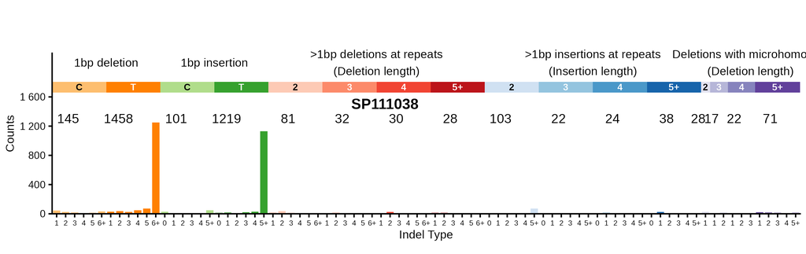

**Click here to see with insertions and deletions of T in long poly-T suppressed**

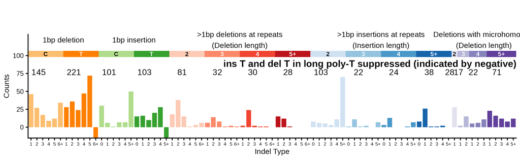